# Curious Glimmerroot

[figure not shown]

Hearthstone has always been friendly towards new players, and many of its mechanics and design philosophies are simplified to make the game easy to pick up and play. Curious Glimmerroot is an outlier to this, both in its complexity and in the skill-set it rewards.

The cards very unique battlecry is shown to the right. For a start, that’s 19 whole words on a card, anathema for team 5! Secondly, its asking you to know what *your opponent* is doing, which is an important skill to master but never before rewarded so tangibly. Finally, its one of the only cards with effect identical in appearance to discover, leading to potential confusion. Luckily its an epic, imagine cracking this guy in a welcome pack, it would be completely overwhelming!

But in all seriousness its this uniqueness that makes the card so popular among the established player community. It always feels good when you pick correctly and its a lot of fun to try. The following article is an investigation of this most curious minions battlecry, and how it seperates the contenders from the pretenders on ladder.

### Glimmerroot, the ultimate test of skill?

Have you ever wondered how often people get it right? Well the short answer is 81% of the time!

The long answer is a little more interesting. Curious Glimmerroot is a card that rewards a players knowledge of the overall meta-game, however you can circumvent all of that by just waiting to *see* what’s in you opponents deck. In theory, we should see a correlation between the turn the card was played, the skill (rank) of the player and the chance they chance they will chose correctly.

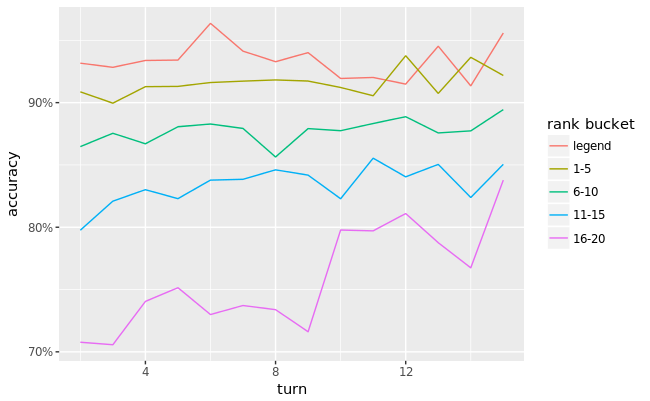

The trend of success with turn is different across the different rank buckets. Rank 15-20 players are almost 10% more likely to pick correctly by turn-10 compared to turn-2, whereas a rank 5-10 or legend player really doesn’t see any improvement. Of course, whether this effect is a result of a lack-of knowledge of the meta-game, or the wider deck diversity at lower rank (as players might not have as complete collections) is up for debate.

There is daylight between the probabilities of success across the different rank buckets when the card is played in the early game. Many argue that hearthstone laddering is a pure numbers game, with rank merely being a measure of how many games you could squeeze into a season. Figure 1 directly contradicts that notion, and provides a concrete example of how players of better rank are measurably more knowledgeable about the overall meta-game. Turn-2 or 3 Glimmerroot success, a proxy for a players overall knoweledge of the meta, does indeed differentiate a good rank 5 player from a legend player.

But what about other modes? Wild lets you play with every card ever printed, leading to a much wider range of potential options and in arena, your deck is generated semi-randomly! What chance do you have picking correctly?

**Figure 2: Probability of successfully picking the correct card when playing Curious Glimmerroot by game mode and the turn the card was played.**

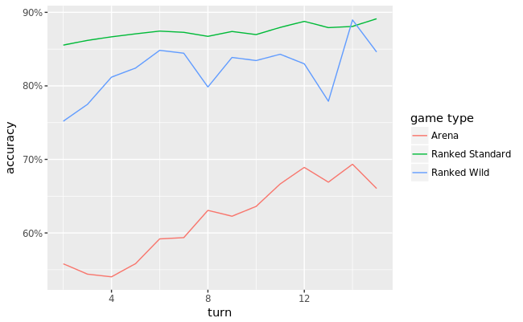

Wild appears to be have around a 5% penalty over ranked, however the player base is quite different. Anecdotally, Wild is played less competitively by many and its certainly far less popular (10:1 Standard vs. Wild games recorded) which may lead contribute to this poorer performance.

Arena is a different story, and your chance of picking correctly before turn 5 is pretty terrible (remember, pure chance is 33%). So in theory you should wait if you want to win the value game, however Arena has been tempo oriented for a long time now. Waiting is generally not a good idea in arena. Hearth-Arena [rates the card as “above average”](http://www.heartharena.com/tierlist) in the class, whereas guaranteed card generation tools like Kabal Courier, Stonehill Defender and Crystalline Oracle are classed as “Good”, perhaps for this reason.

### Its a trap!

Some cards are harder to pick than other, for example if you a see a quest you can be fairly sure if it started in your opponents deck given they either played it or didn’t on turn-1. On the other hand, some are much harder, particularly those that see fringe play. So what cards are being shown and fooling players most frequently?

[output not shown]

Oh, and if your offered Explosive Trap… its probably a trap.